## Libraries that we will use

```r
####### For graphics #####################
library(ggplot2)


###### For data manipulation #############
library(tidyverse)



###### For missingness ###################
library(visdat)
library(mice)



###### Encoders ##########################
library(vtreat)



###### Algorithms collection #############
library(caret)
```

## Load the dataset

```r
SLD <- read.csv("train.csv",
                na.strings = c(""))
```

## Exploring data using summary statistics

```r
# command which reveals how the object's storage is implemented
cat("How object's storage is implemented:",typeof(SLD),"\n")
```

```
## How object's storage is implemented: list
```

```r
# what kind of object we have
cat("What kind of object's we have:",class(SLD),"\n")
```

```
## What kind of object's we have: data.frame
```

```r
# dimension of dataset
cat("Dimensions of our object",dim(SLD),"\n")
```

```
## Dimensions of our object 891 12
```

```r
# structure of our data
str(SLD)
```

```
## 'data.frame':    891 obs. of  12 variables:
##  $ PassengerId: int  1 2 3 4 5 6 7 8 9 10 ...
##  $ Survived   : int  0 1 1 1 0 0 0 0 1 1 ...
##  $ Pclass     : int  3 1 3 1 3 3 1 3 3 2 ...
##  $ Name       : chr  "Braund, Mr. Owen Harris" "Cumings, Mrs. John Bradley (Florence Briggs Thayer)" "Heikkinen, Miss. Laina" "Futrelle, Mrs. Jacques Heath (Lily May Peel)" ...
##  $ Sex        : chr  "male" "female" "female" "female" ...
##  $ Age        : num  22 38 26 35 35 NA 54 2 27 14 ...
##  $ SibSp      : int  1 1 0 1 0 0 0 3 0 1 ...
##  $ Parch      : int  0 0 0 0 0 0 0 1 2 0 ...
##  $ Ticket     : chr  "A/5 21171" "PC 17599" "STON/O2. 3101282" "113803" ...
##  $ Fare       : num  7.25 71.28 7.92 53.1 8.05 ...
##  $ Cabin      : chr  NA "C85" NA "C123" ...
##  $ Embarked   : chr  "S" "C" "S" "S" ...
```

```r
# summary of our data
summary(SLD)
```

```
##   PassengerId       Survived          Pclass          Name
##  Min.   :  1.0   Min.   :0.0000   Min.   :1.000   Length:891
##  1st Qu.:223.5   1st Qu.:0.0000   1st Qu.:2.000   Class :character
##  Median :446.0   Median :0.0000   Median :3.000   Mode  :character
##  Mean   :446.0   Mean   :0.3838   Mean   :2.309
##  3rd Qu.:668.5   3rd Qu.:1.0000   3rd Qu.:3.000
##  Max.   :891.0   Max.   :1.0000   Max.   :3.000
##
##      Sex                 Age            SibSp           Parch
##  Length:891         Min.   : 0.42   Min.   :0.000   Min.   :0.0000
##  Class :character   1st Qu.:20.12   1st Qu.:0.000   1st Qu.:0.0000
##  Mode  :character   Median :28.00   Median :0.000   Median :0.0000
##                     Mean   :29.70   Mean   :0.523   Mean   :0.3816
##                     3rd Qu.:38.00   3rd Qu.:1.000   3rd Qu.:0.0000
##                     Max.   :80.00   Max.   :8.000   Max.   :6.0000
##                     NA's   :177
##     Ticket               Fare           Cabin             Embarked
##  Length:891         Min.   :  0.00   Length:891         Length:891
##  Class :character   1st Qu.:  7.91   Class :character   Class :character
##  Mode  :character   Median : 14.45   Mode  :character   Mode  :character
##                     Mean   : 32.20
##                     3rd Qu.: 31.00
##                     Max.   :512.33
##
```

## Which of our variables are categorical

```r
outcome <- "Q1821" # random string not the same as colnames
vars <- setdiff(colnames(SLD), outcome)
is_categorical <- vapply(SLD[, vars],
                         function(v) !is.numeric(v),
                         logical(1))

is_categorical
```

```
## PassengerId    Survived      Pclass        Name         Sex         Age
##       FALSE       FALSE       FALSE        TRUE        TRUE       FALSE
##       SibSp       Parch      Ticket        Fare       Cabin    Embarked
##       FALSE       FALSE        TRUE       FALSE        TRUE        TRUE
```

```r
summary(is_categorical)
```

```
##    Mode   FALSE    TRUE
## logical       7       5
```

## Count the levels of categorical variables

```
##     Name      Sex   Ticket    Cabin Embarked
##      891        2      681      148        4
```

```r
summary(nlevels)
```

```
##    Min. 1st Qu.  Median    Mean 3rd Qu.    Max.
##     2.0     4.0   148.0   345.2   681.0   891.0
```

## Number of missing data

```
## PassengerId    Survived      Pclass        Name         Sex         Age
##           0           0           0           0           0         177
##       SibSp       Parch      Ticket        Fare       Cabin    Embarked
##           0           0           0           0         687           2
```

```
##    Min. 1st Qu.  Median    Mean 3rd Qu.    Max.
##    0.00    0.00    0.00   72.17    0.50  687.00
```

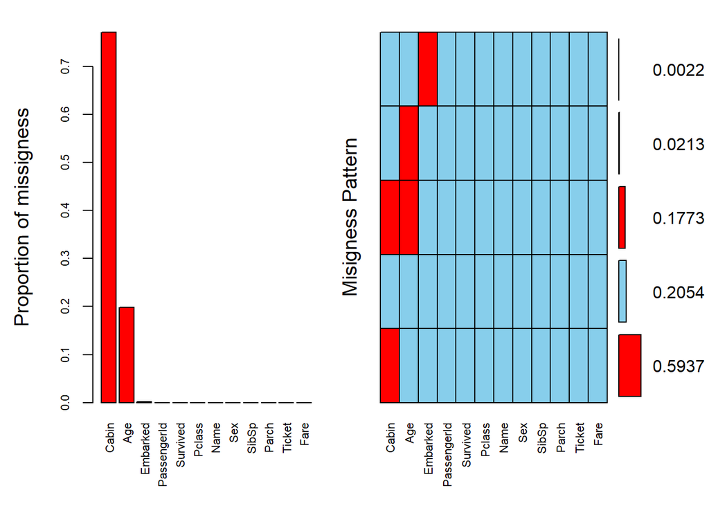

```
##
##  Variables sorted by number of missings:
##     Variable       Count
##        Cabin 0.771043771
##          Age 0.198653199
##     Embarked 0.002244669
##  PassengerId 0.000000000
##     Survived 0.000000000
##       Pclass 0.000000000
##         Name 0.000000000
##          Sex 0.000000000
##        SibSp 0.000000000
##        Parch 0.000000000
##       Ticket 0.000000000
##         Fare 0.000000000
```

```r
miss <-VIM::aggr(SLD,
              numbers = T,
             sortVars = T, labels=names(SLD),
             cex.axis =.7,
                  gap = 3,
                 ylab = c("Proportion of missigness",
                    "Misigness Pattern"))
```

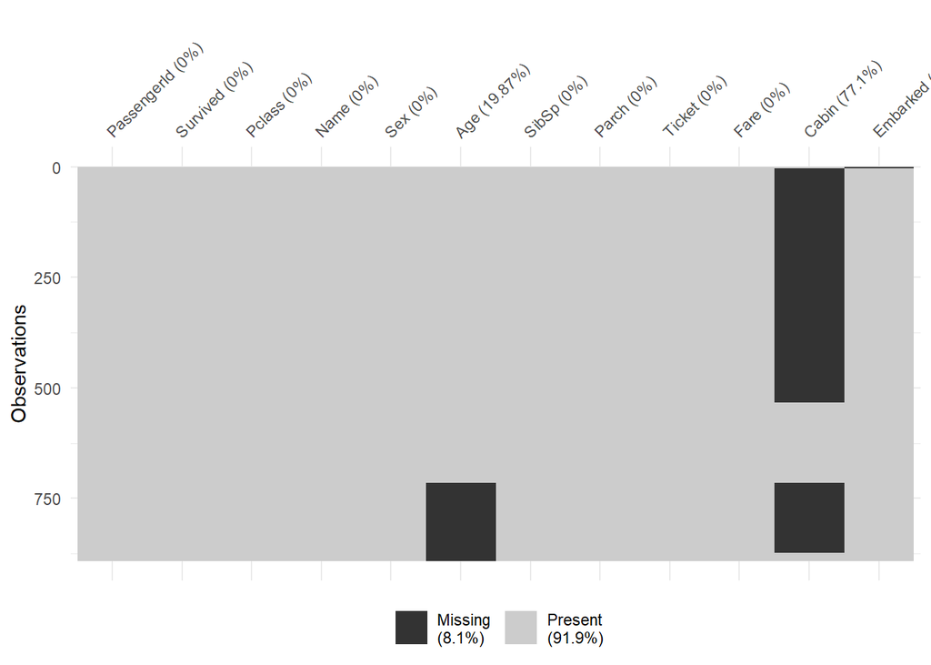

```r
vis_miss(SLD,cluster = T)
```

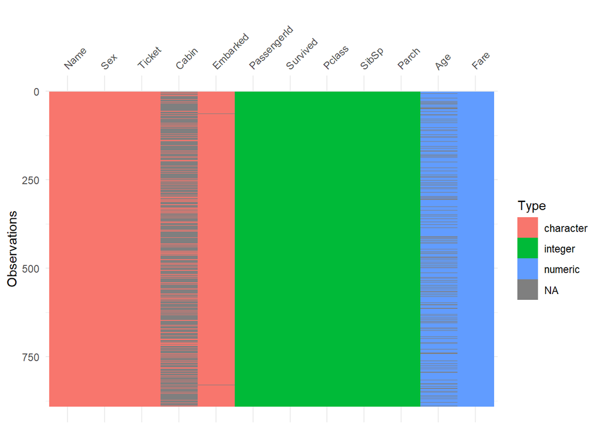

```r
vis_dat(SLD)
```

## Find duplicates

```r
x <- as.factor(SLD$Ticket)
str(x)
```

```
##  Factor w/ 681 levels "110152","110413",..: 524 597 670 50 473 276 86 396 345 133 ...
```

```r
summary(x)
```

```
##          1601        347082      CA. 2343       3101295        347088
##             7             7             7             6             6
##       CA 2144        382652  S.O.C. 14879        113760        113781
##             6             5             5             4             4
##         17421         19950          2666        347077        349909
##             4             4             4             4             4
##          4133          LINE      PC 17757    W./C. 6608        110152
##             4             4             4             4             3
##        110413         13502        230080        239853         24160
##             3             3             3             3             3
##        248727         29106        345773        347742         35273
##             3             3             3             3             3
##        363291        371110    C.A. 31921    C.A. 34651  F.C.C. 13529
##             3             3             3             3             3
##      PC 17572      PC 17582      PC 17755      PC 17760 SC/Paris 2123
```

[output cut: 25 more lines]

Βλέπουμε ότι έχουμε πολλά duplicates στην μεταβλητή “Ticket” οπότε και θα τα αφαιρέσουμε.

## Data wrangling - Feature Engineering

Θα φτιάξουμε μία καινούργια μεταβλητή “Title” η οποία θα είναι οι τίτλοι ευγενείας για τους επιβάτες του πλοίου, βασισμένη στην μεταβλητή “Name”.

```r
# Grab title from passenger names
SLD$Title <- gsub('(.*, )|(\\..*)', '', SLD$Name)

# Show title counts by sex
table(SLD$Sex, SLD$Title)
```

```
##
##          Capt Col Don  Dr Jonkheer Lady Major Master Miss Mlle Mme  Mr Mrs  Ms
##   female    0   0   0   1        0    1     0      0  182    2   1   0 125   1
##   male      1   2   1   6        1    0     2     40    0    0   0 517   0   0
##
##          Rev Sir the Countess
##   female   0   0            1
##   male     6   1            0
```

```r
# Titles with very low cell counts to be combined to "rare" level
rare_title <- c('Dona', 'Lady', 'the Countess','Capt', 'Col', 'Don',
                'Dr', 'Major', 'Rev', 'Sir', 'Jonkheer')

# Also reassign mlle, ms, and mme accordingly
SLD$Title[SLD$Title == 'Mlle']        <- 'Miss'
SLD$Title[SLD$Title == 'Ms']          <- 'Miss'
SLD$Title[SLD$Title == 'Mme']         <- 'Mrs'
SLD$Title[SLD$Title %in% rare_title]  <- 'Rare Title'

# Show title counts by sex again
table(SLD$Sex, SLD$Title)
```

```
##
##          Master Miss  Mr Mrs Rare Title
##   female      0  185   0 126          3
##   male       40    0 517   0         20
```

Θα “πετάξουμε” έξω από το dataset την μεταβλητή “Cabin” γιατί οπως είδαμε περιέχει πολλά ΝΑ (77%). Θα “πετάξουμε” επίσης έξω το “Ticket” γιατί έχει πολλά duplicate.Τέλος θα “πετάξουμε” έξω το “Name” και το “PassngerId” γιατί δεν πιστεύουμε ότι θα βοηθήσουν στις προβλέψεις.

```r
SLD <- select(SLD ,-c("Cabin",
                      "Name",
                      "PassengerId",
                      "Ticket"))
```

## Imputation

```r
# which rows have missing values in embarked
SLD[!complete.cases(SLD$Embarked),]
```

|  | Survived | Pclass | Sex | Age | SibSp | Parch | Fare | Embarked | Title |
| --- | --- | --- | --- | --- | --- | --- | --- | --- | --- |
| 62 | 1 | 1 | female | 38 | 0 | 0 | 80 | NA | Miss |
| 830 | 1 | 1 | female | 62 | 0 | 0 | 80 | NA | Mrs |

Παρατηρούμε ότι οι επιβάτες με NA στο “Embarked” έχουν πληρώσει 80 δολλάρια “Fare”

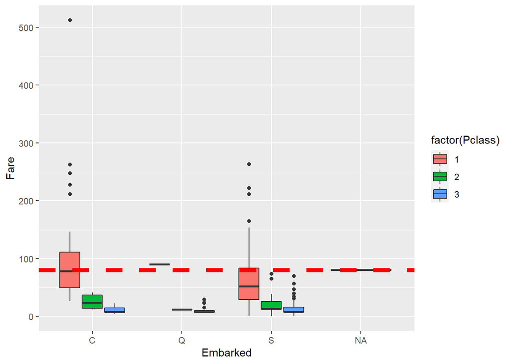

```r
ggplot( data = SLD,
       aes(x = Embarked,
           y = Fare,
        fill = factor(Pclass)))+
  geom_boxplot() +
  geom_hline(aes(yintercept = 80),
      colour ='red',
    linetype ='dashed',
         lwd = 2)
```

Από τα boxplot φαίνεται ότι οι επιβάτες που πλήρωσαν 80 δολλάρια εισιτήριο, μάλλον έχουν επιβιβαστεί από το “C” γιατί η διάμεσος των 80 δολλαριών συμπίπτει με την επιβίβαση από το “C. Συνεπώς είναι πολύ πιθανό οι δύο επιβάτες με NA στο Embarked να έχουν επιβιβαστεί από το”C" γιατί έχουν πληρώσει 80 δολλάρια εισιτήριο.Θα αντικαταστήσουμε τα NA τους με “C”

```r
SLD$Embarked[c(62, 830)] <- 'C'
sum(is.na(SLD$Embarked))
```

```
## [1] 0
```

Είδαμε και ότι η μεταβλητή “Age” περιέχει πολλά ΝΑ. Θα τις αντικαταστήσουμε χρησιμοποιώντας το πακέτο “mice” και μέθοδο “RandomForest”. Μπορούμε να επιλέξουμε να κάνουμε impute και με άλλες μεθόδους όπως “rpart”,“median”,“mean”.

```r
sum(is.na(SLD$Age))
```

```
## [1] 177
```

```r
temp <- mice(SLD,method = "rf")
SLD_imputed <- complete(temp)
```

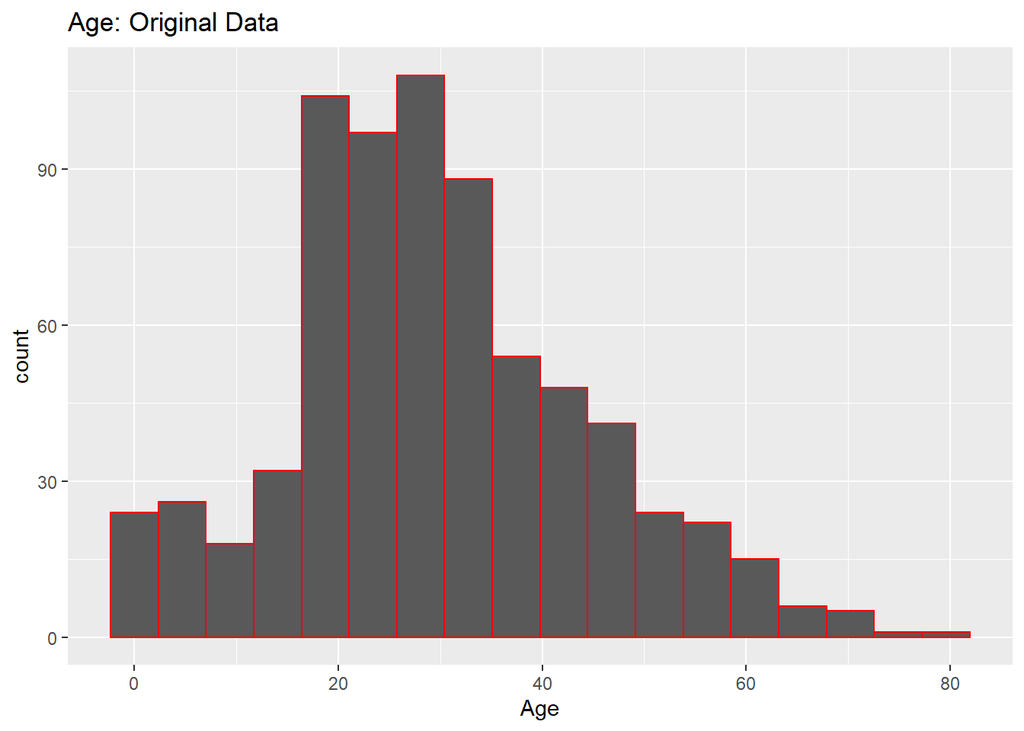

```r
# Plot age distributions

ggplot( data = SLD,
       aes(x = Age,
       color = I("red")))+
        geom_histogram(bins = 18)+
  ggtitle("Age: Original Data")
```

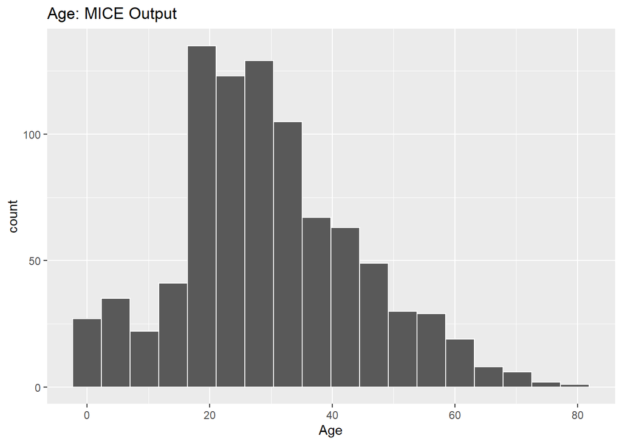

```r
ggplot( data = SLD_imputed,
       aes(x = Age,
       color = I("white")))+
           geom_histogram(bins = 18)+
  ggtitle("Age: MICE Output")
```

Παρατηρούμε ότι τα δύο ιστόγραμματα είναι παρόμοια, συνεπώς το imputation που κάναμε πέτυχε.

## Data visualization

Θα δούμε γραφικά την μεταβλητή που θέλουμε να προβλέψουμε.

```
##
##
##    Cell Contents
## |-------------------------|
## |                       N |
## |         N / Table Total |
## |-------------------------|
##
##
## Total Observations in Table:  891
##
##
##           |         0 |         1 |
##           |-----------|-----------|
##           |       549 |       342 |
##           |     0.616 |     0.384 |
##           |-----------|-----------|
##
##
##
##
```

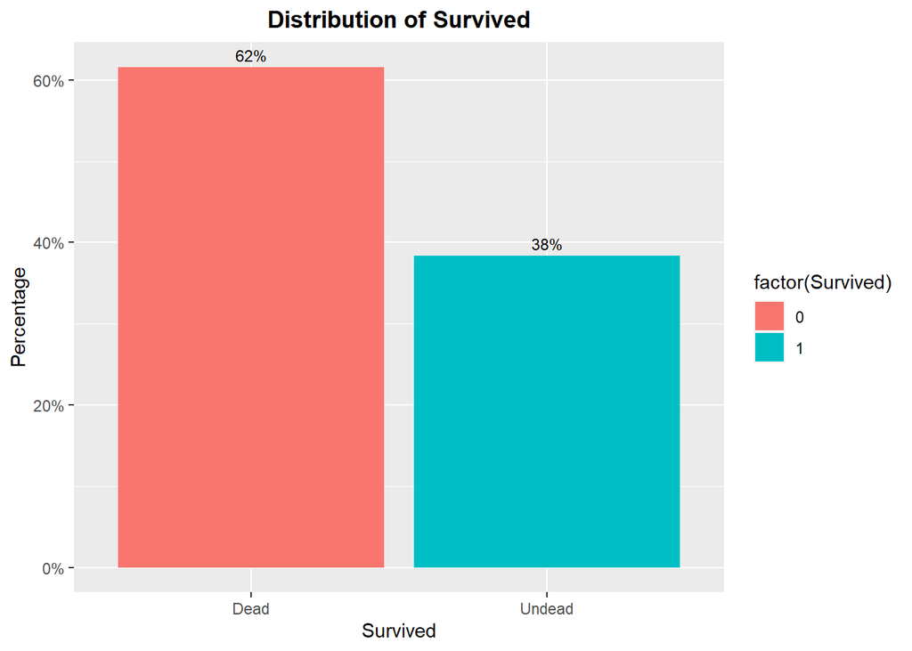

Τώρα θα κάνουμε περισσότερα plots για να εξετάσουμε γραφικά την σχέση των μεταβλητών μας με την τιμή που θέλουμε να προβλέψουμε

```r
str(temp)
```

```
## 'data.frame':    891 obs. of  9 variables:
##  $ Survived: int  0 1 1 1 0 0 0 0 1 1 ...
##  $ Pclass  : int  3 1 3 1 3 3 1 3 3 2 ...
##  $ Sex     : chr  "male" "female" "female" "female" ...
##  $ Age     : num  22 38 26 35 35 28 54 2 27 14 ...
##  $ SibSp   : int  1 1 0 1 0 0 0 3 0 1 ...
##  $ Parch   : int  0 0 0 0 0 0 0 1 2 0 ...
##  $ Fare    : num  7.25 71.28 7.92 53.1 8.05 ...
##  $ Embarked: chr  "S" "C" "S" "S" ...
##  $ Title   : chr  "Mr" "Mrs" "Miss" "Mrs" ...
```

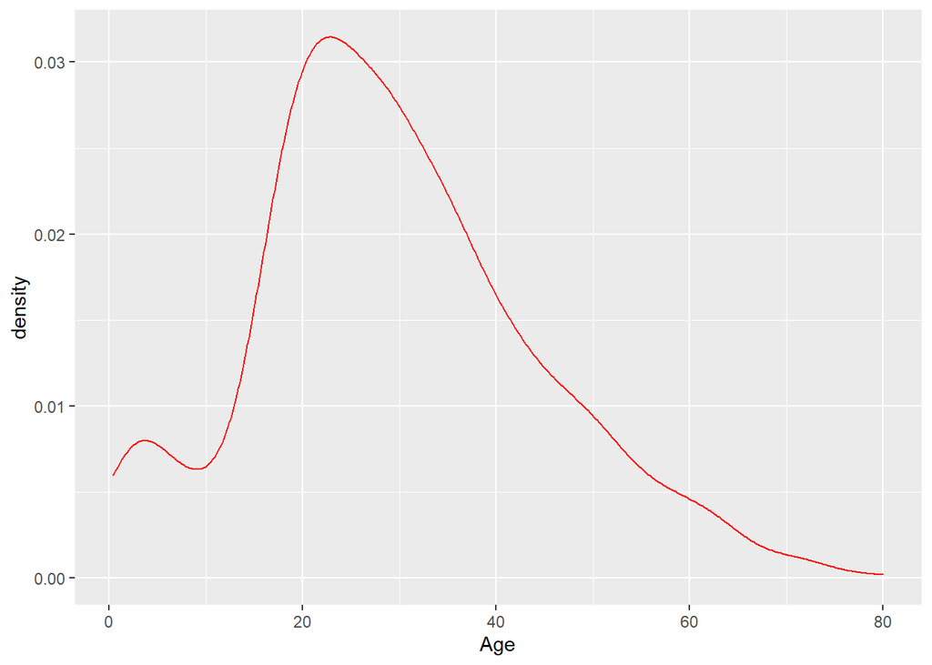

```r
ggplot( data = temp,
       aes(x = Age))+
       geom_density(color = I("red"))
```

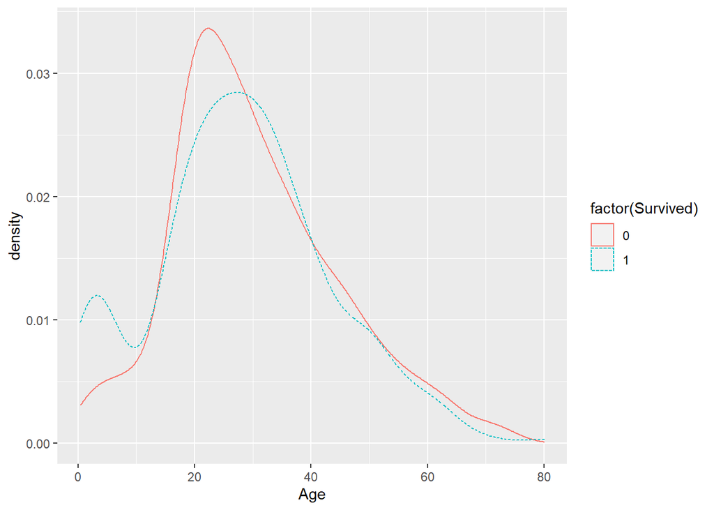

```r
ggplot (data = temp,
       aes(x = Age,
       color = factor(Survived),
    linetype = factor(Survived)))+
       geom_density()
```

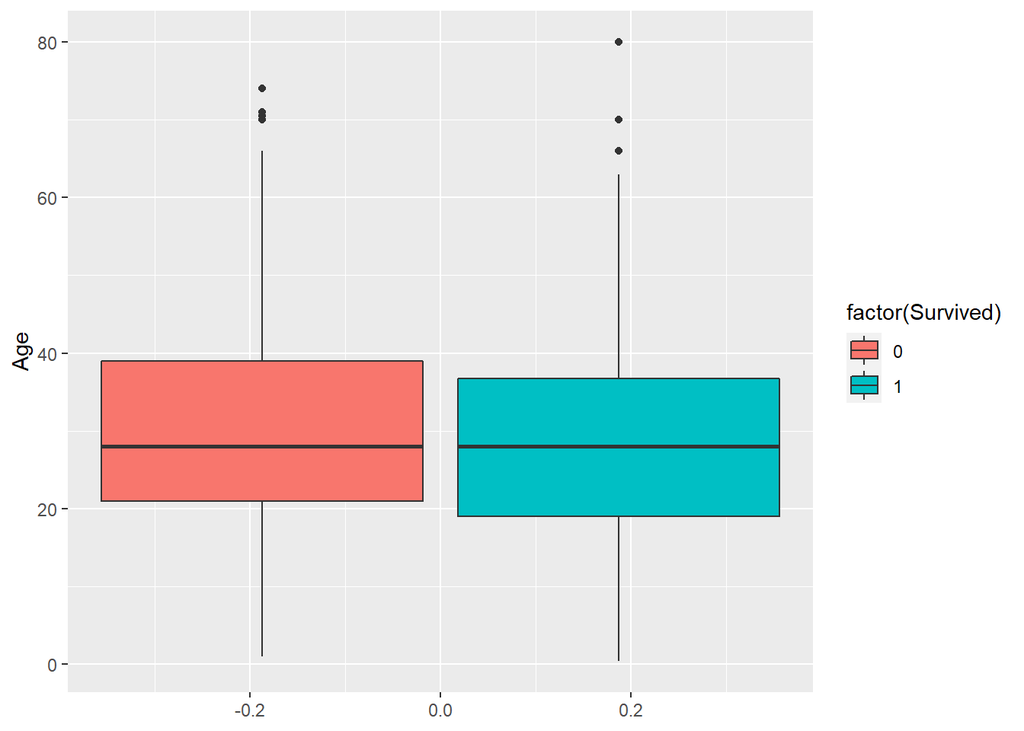

```r
ggplot(data = temp,
      aes(y = Age,
       fill = factor(Survived)))+
       geom_boxplot()
```

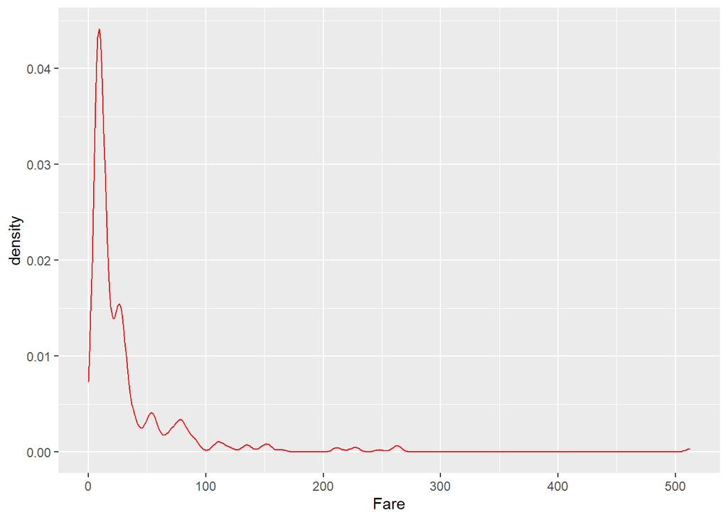

```r
ggplot( data = temp,
       aes(x = Fare))+
       geom_density(color = I("red"))
```

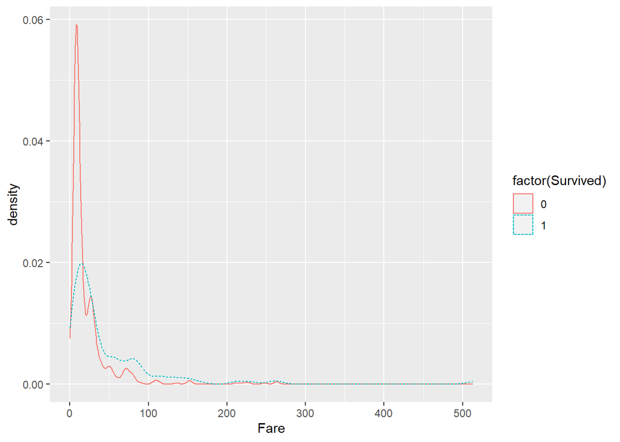

```r
ggplot (data = temp,
       aes(x = Fare,
       color = factor(Survived),
    linetype = factor(Survived)))+
       geom_density()
```

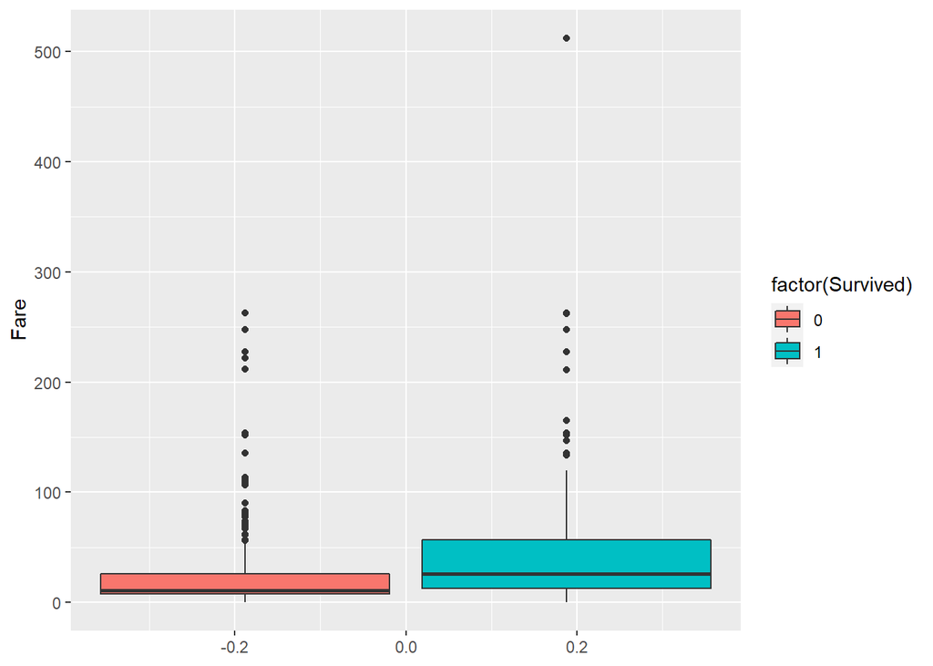

```r
ggplot(data = temp,
      aes(y = Fare,
       fill = factor(Survived)))+
       geom_boxplot()
```

Κρίνοντας από τα density plots βλέπουμε ότι η μεταβλητή “Fare” έχει άμεση σχέση με την μεταβλητή “Survived”. Επίσης βλέπουμε ότι παρουσιάζει θετική ασσυμετρία, οπότε ανάλογα τον αλγόριθμο που θα χρησιμοποιήσουμε, ίσως χρειαστεί να κάνουμε normalization στην μεταβλητή αυτή. Τέλος από τα boxplots βλέπουμε ότι έχουμε πολλά outliers, οπότε μία ιδέα είναι να χρησιμοποιήσουμε τον αλγόριθμο RandomForest για να κάνουμε τις προβλέψεις μας γιατί είναι γενικά πολύ σταθερός σε dataset με outliers.

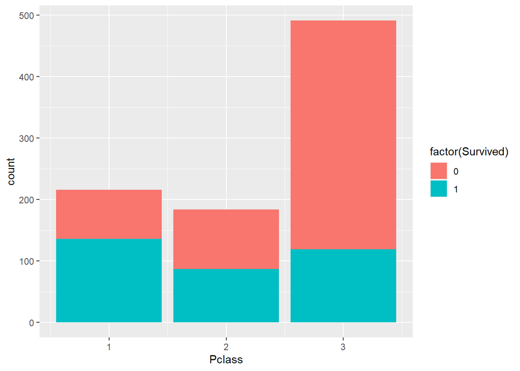

```r
ggplot(data = temp,
      aes(x = Pclass,
       fill = factor(Survived)))+
       ylab("count")+
       xlab("Pclass")+
       geom_bar()
```

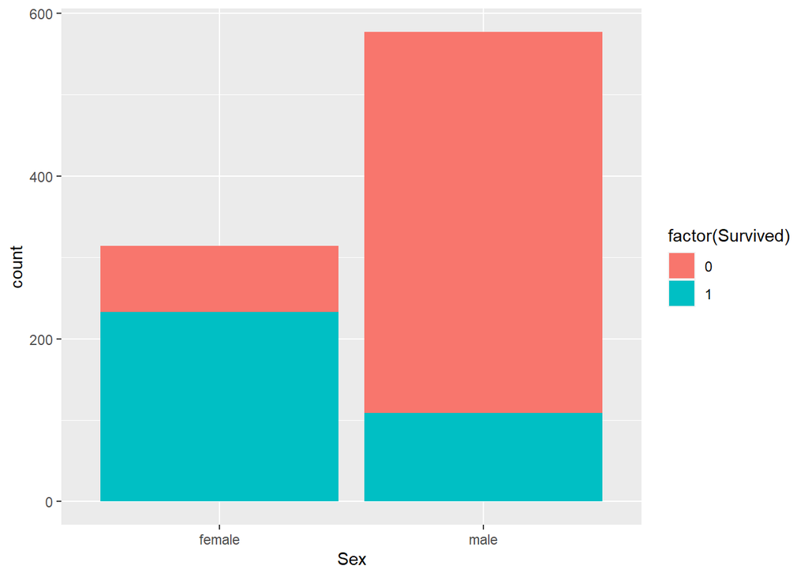

```r
ggplot(data = temp,
      aes(x = Sex,
       fill = factor(Survived)))+
       ylab("count")+
       xlab("Sex")+
       geom_bar()
```

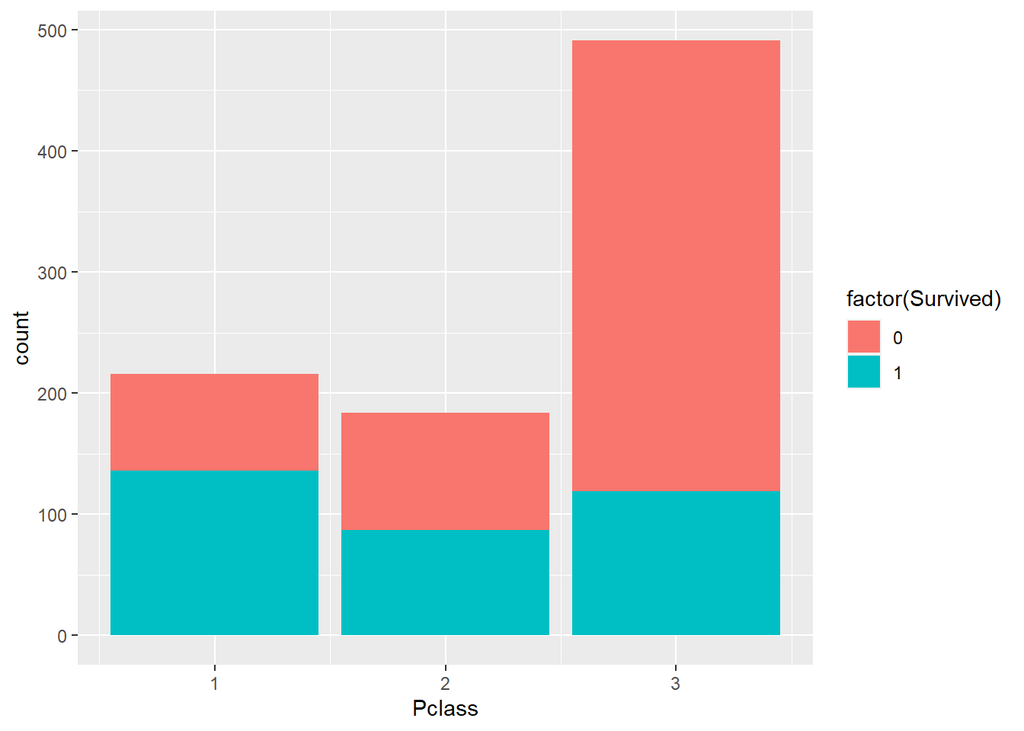

```r
ggplot(data = temp,
      aes(x = Pclass,
       fill = factor(Survived)))+
       ylab("count")+
       xlab("Pclass")+
       geom_bar()
```

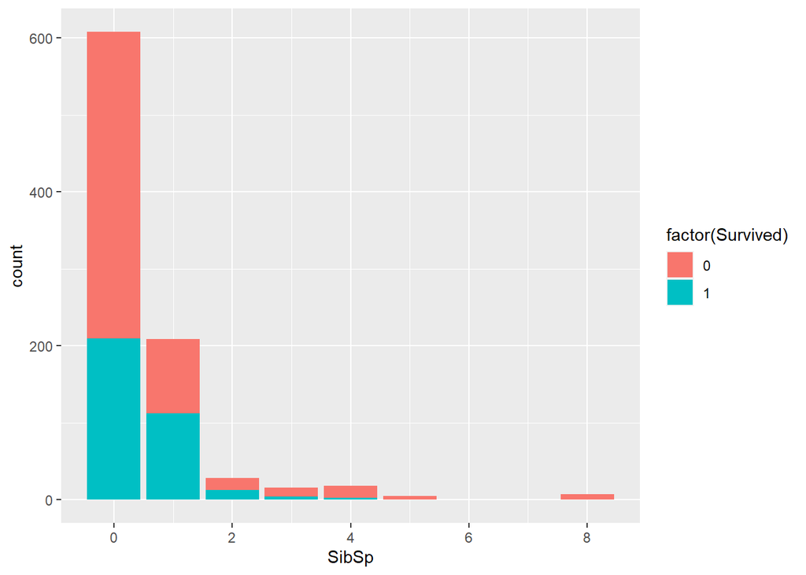

```r
ggplot(data = temp,
      aes(x = SibSp,
       fill = factor(Survived)))+
       ylab("count")+
       xlab("SibSp")+
       geom_bar()
```

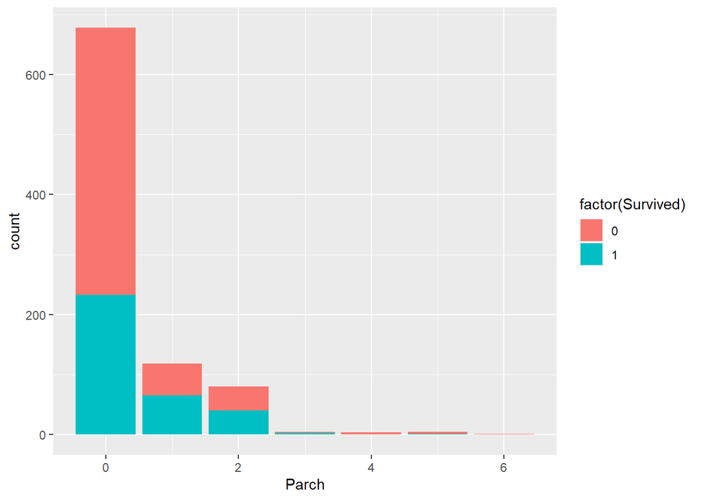

```r
ggplot(data = temp,
      aes(x = Parch,
       fill = factor(Survived)))+
       ylab("count")+
       xlab("Parch")+
       geom_bar()
```

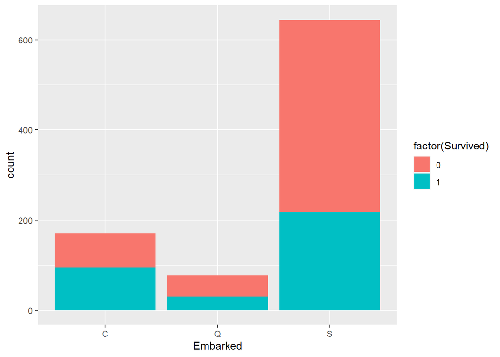

```r
ggplot(data = temp,
      aes(x = Embarked,
       fill = factor(Survived)))+
       ylab("count")+
       xlab("Embarked")+
       geom_bar()
```

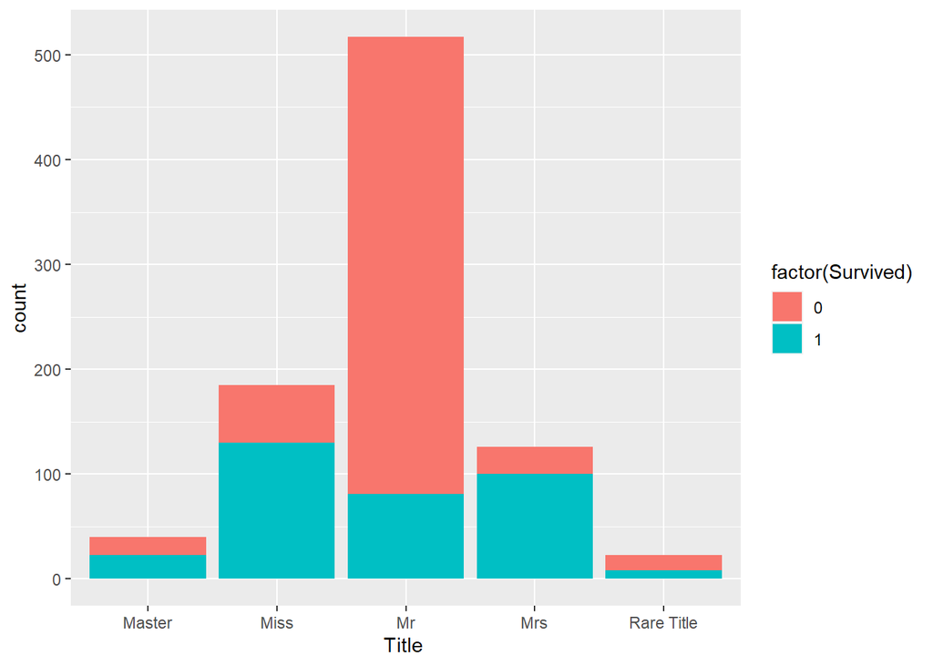

```r
ggplot(data = temp,
      aes(x = Title ,
       fill = factor(Survived)))+
       ylab("count")+
       xlab("Title ")+
       geom_bar()
```

## Remove zero and near zero variance features(if any)

```
## 'data.frame':    9 obs. of  4 variables:
##  $ freqRatio    : num  1.61 2.27 1.84 1.08 2.91 ...
##  $ percentUnique: num  0.224 0.337 0.224 9.877 0.786 ...
##  $ zeroVar      : logi  FALSE FALSE FALSE FALSE FALSE FALSE ...
##  $ nzv          : logi  FALSE FALSE FALSE FALSE FALSE FALSE ...
```

## Data spliting

```r
# for reproducibility
seed <- 1821
set.seed(seed)


 inTrain  <- createDataPartition(y = temp$Survived,
                                 p = 0.75,
                              list = F)

 training <- temp[ inTrain,]    # training set
 testing  <- temp[-inTrain,]    # testing set
```

## Correlation

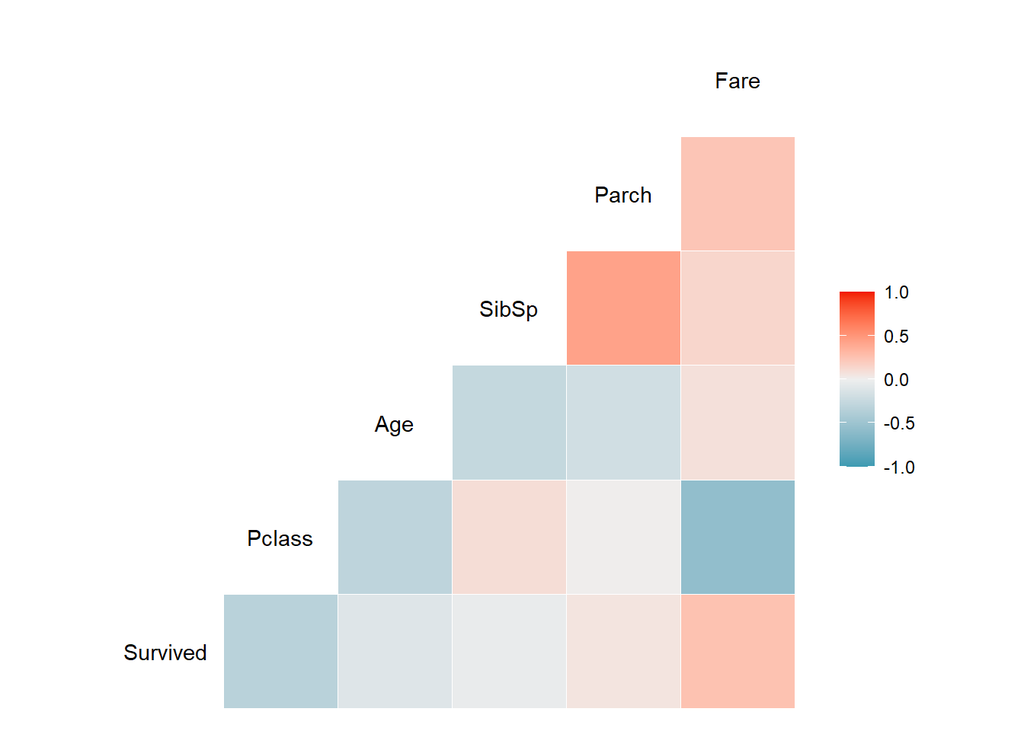

```r
GGally::ggcorr(training)
```

## Encoding

```r
vars <- setdiff(colnames(training),c("Survived"))
outcome <- "Survived"


unpack[
    transform = treat_m,      # treatment plan
   d_prepared = cross_frame,  # treated training data
  score_frame = score_frame
]<-vtreat::mkCrossFrameMExperiment(
                             training,
                              vars,
                              outcomename = outcome)


daTrain <- d_prepared
daTest  <- vtreat::prepare(transform,testing)
```

Εδώ χρησιμοποιούμε το πακέτο vtreat για να κάνουμε “target encode” και “dummy encode” τις κατηγορικές μας μεταβλητές. Το “target encode” είναι μία πολύ δημοφιλής μέθοδος που χρησιμοποιείται από πολλούς στο kagle.Ωστόσο πρέπει να εφαρμοστεί σωστά γιατί διαφορετικά οδηγεί σε overfitting.To πακέτο vtreat το κάνει αυτό για μας , οπότε δεν χρειάζεται να ανησυχούμε αν κάναμε σωστά “target encode”.

Εδω με την βοήθεια του πακέτου vtreat επιλέγουμε κάποιες μεταβλητές που φαίνεται να έχουν μεγαλύτερη επίδραση πάνω στην μεταβλητή που θέλουμε να προβλέψουμε. Αυτές είναι

```r
good_new_variables <- unique(score_frame[score_frame[["recommended"]],
                             "varName",
                              drop = T])
```

```r
good_new_variables
```

```
##  [1] "Age"              "Embarked_catP"    "Embarked_lev_x_C" "Embarked_lev_x_S"
##  [5] "Fare"             "Pclass"           "Sex_lev_x_female" "Sex_lev_x_male"
##  [9] "Title_catP"       "Title_lev_x_Miss" "Title_lev_x_Mr"   "Title_lev_x_Mrs"
## [13] "X0_Sex_catB"      "X0_Embarked_catB" "X0_Title_catB"    "X1_Sex_catB"
## [17] "X1_Embarked_catB" "X1_Title_catB"
```

## Fit a model

```r
set.seed(seed)
metric <- "Accuracy"


# 10 fold cross validation repeated 5 times
ctrl   <- trainControl(
                       method  = "repeatedcv",
                       number  = 10,
                       repeats = 5

)



# model_vars <-score_frame$varName # to use all variables
  model_vars <- good_new_variables


fit.rf <- train(
                       x = as.matrix(daTrain[,model_vars,drop = F]),
                       y = daTrain[["Survived"]],
                  method = "rf",
                  metric = metric,
               trControl = ctrl,
              tuneLength = 20,
                   ntree = 100,
              respect.unordered.factors = "order",

)
```

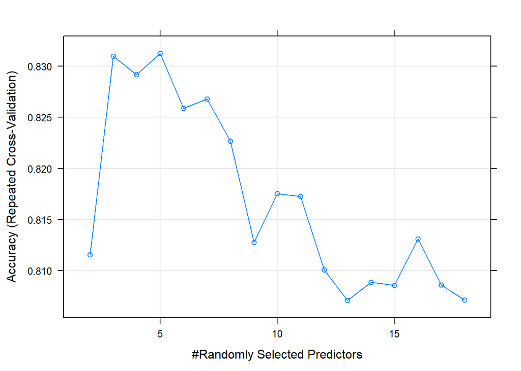

```r
plot(fit.rf)
```

```r
print(fit.rf)
```

```
## Random Forest
##
## 669 samples
##  18 predictor
##   2 classes: '0', '1'
##
## No pre-processing
## Resampling: Cross-Validated (10 fold, repeated 5 times)
## Summary of sample sizes: 601, 601, 602, 602, 601, 603, ...
## Resampling results across tuning parameters:
##
##   mtry  Accuracy   Kappa
##    2    0.8115540  0.5902929
##    3    0.8309995  0.6265215
##    4    0.8291947  0.6211871
##    5    0.8312709  0.6265177
##    6    0.8258886  0.6162209
##    7    0.8268018  0.6186507
##    8    0.8226624  0.6105870
##    9    0.8127527  0.5913051
##   10    0.8175426  0.6019576
##   11    0.8172530  0.6018008
##   12    0.8100745  0.5875095
##   13    0.8070757  0.5820034
##   14    0.8088759  0.5856399
##   15    0.8085732  0.5851836
##   16    0.8130960  0.5950610
##   17    0.8086175  0.5841547
##   18    0.8071292  0.5821150
##
## Accuracy was used to select the optimal model using the largest value.
## The final value used for the model was mtry = 5.
```

```r
fit.rf$finalModel
```

```
##
## Call:
##  randomForest(x = x, y = y, ntree = 100, mtry = param$mtry, respect.unordered.factors = "order")
##                Type of random forest: classification
##                      Number of trees: 100
## No. of variables tried at each split: 5
##
##         OOB estimate of  error rate: 17.94%
## Confusion matrix:
##     0   1 class.error
## 0 380  33  0.07990315
## 1  87 169  0.33984375
```

```r
pred1 <- predict(fit.rf,newdata = daTest,type = "raw")
confusionMatrix(pred1,as.factor(daTest$Survived))
```

```
## Confusion Matrix and Statistics
##
##           Reference
## Prediction   0   1
##          0 125  26
##          1  11  60
##
##                Accuracy : 0.8333
##                  95% CI : (0.7777, 0.8799)
##     No Information Rate : 0.6126
##     P-Value [Acc > NIR] : 7.039e-13
##
##                   Kappa : 0.6372
##
##  Mcnemar's Test P-Value : 0.02136
##
##             Sensitivity : 0.9191
##             Specificity : 0.6977
##          Pos Pred Value : 0.8278
##          Neg Pred Value : 0.8451
##              Prevalence : 0.6126
##          Detection Rate : 0.5631
##    Detection Prevalence : 0.6802
##       Balanced Accuracy : 0.8084
##
##        'Positive' Class : 0
##
```

## Importance

Εδω βλέπουμε τις 10 πιο σημαντικές μεταβλητές που χρησιμοποιεί ο αλγόριθμος για να κάνει την πρόβλεψη.

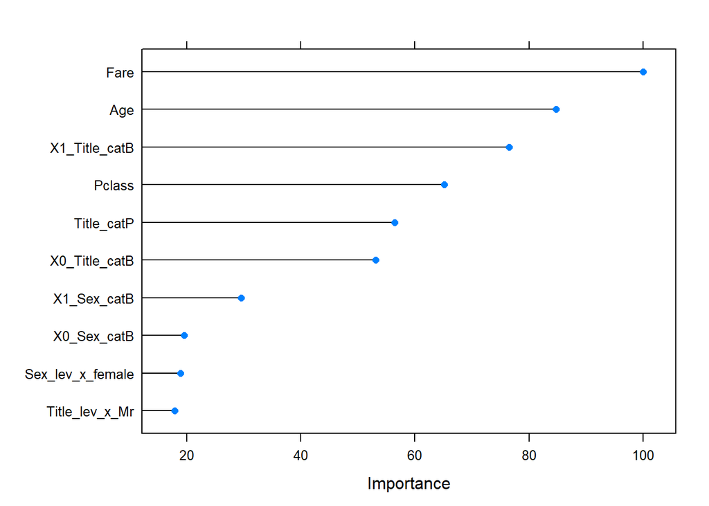

```r
var.imp <- varImp(fit.rf)
plot(var.imp,
     top = 10)
```